# Project 2

STATS 220 Semester One 2023

Matthew Sum

2023-03-25

## Introudction

For my survey, I decided to focus on sports. I wanted to find out about the learning practices people have around sports and their reasons for learning a new sport.

When designing my form, I made sure to follow guideline 4. For short answer questions, such as “How many sports are you proficient in?”, I ensured that only numbers could be entered, and set a range between 0-100. I included 0 because there is a chance that the respondent may not play any sports proficiently.

The Google Sheet data collected will not be *tidy* because the data collected from the check boxes are grouped into one cell where the selected options are separated by a comma. This means that the data is not *tidy* due to the selected options not having a column (or cell) of their own.

[Here is the link to my google form](https://forms.gle/PNff5W5uER2gcnRN8)

## Analytics

[Here is the link to my CSV file](https://docs.google.com/spreadsheets/d/e/2PACX-1vSQqXbmfR2IkXBu9QfDVmG-j57sb0C5nfwqiKiT15EXpJGBHPXjYYDrXmeSXojVmmeSx9EeEJzaRs7i/pub?output=csv)

```
## [1] "The median for number of sports watched is 4"
```

```
## [1] "The mean number of hours put into learning a new sport is 2.04"
```

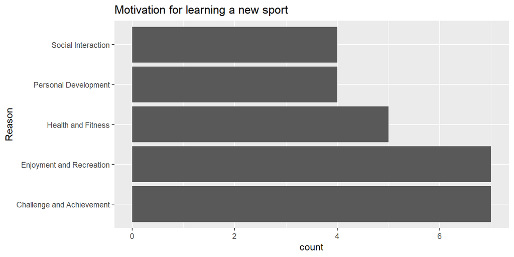

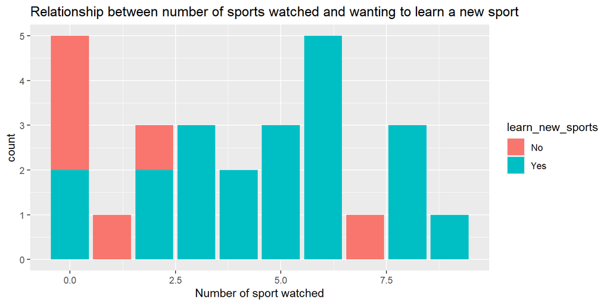

In total, 27 people completed my form.

## Learning reflection

I learned a lot of things from module 2, but the four guidelines were the most memorable. Guideline 1 was especially memorable, as originally, I was just thinking of creating a form with questions and distributing the form to gather responses. However, Guideline 1 taught me that each form must have a clear introduction that explains the purpose of data collection and what the data is being used for. Guideline 3 also taught me to consider my respondents before writing my questions. As the majority of people conducting my survey will be university students, I made sure to include options/questions that were suited to my respondents. My project demonstrates creativity in the form of my survey. I made my form green, added colour to it, and attached an image as the header. This was not necessary for Project 2, but I wanted to make my form more aesthetically pleasing and to suit the theme of my questions. I also added CSS, covered in module 1 and stuck with the colour green as this colour often represents sports which was the theme of my survey. I am curious about the data tidying aspect of data technologies. I think that creating surveys is generally straightforward and not that difficult. However, I would like to explore how companies tidy their data after large surveys. For surveys that contain many questions and a variety of answers, it would be difficult to manipulate the data to create graphs or tables to analyse or develop conclusions from the data. I also believe knowing how to manipulate data is a useful skill to have.